# Model4

RW Hass

2024-02-26

## Load the data

```r
HSB <- read.csv("HSB_data.csv")

# to make public = 0
HSB$sector <- factor(HSB$sector, levels=c("Public", "Catholic"))
```

### Run model 4 - Intercepts and Slopes as Outcomes

Running model 4 means specifying the cross level interactions. This is sort of tricky, but essentially, you want an interaction term between any level-1 predictor with random slope and any level-2 predictor that is “predicting” that random variation.

This is easier if we look at the Hierarchical version of the model again:

- Level 1
  - $Y_{ij} = \beta_{0j} + \beta_{1j}(cses_{ij}) + r_{ij}$
- Level 2
  - $\beta_{0j} = \gamma_{00} + \gamma_{01}(mean.ses_{j}) + \gamma_{02}(Sector_{j}) + u_{0j}$
  - $\beta_{1j} = \gamma_{10} + \gamma_{11}(mean.ses_{j}) + \gamma_{12}(Sector_{j}) + u_{1j}$

So we know we have 3 predictor variables: cses (at level 1) and mean.ses and sector at level 2 Why do we need to specify interactions again?

Because the combined model includes interactions. This is due to the fact that when we substitute the level 2 equation for $\beta_{1j}$ into the level 1 equation, it means the entire level 2 equation is multiplied by $cses_{ij}$ so we have:

$$Y_{ij} = [\gamma_{00} + \gamma_{01}(mean.ses_{j}) +
\gamma_{02}(Sector_{j}) + u_{0j}] + [cses \times (\gamma_{10} +
\gamma_{11}(mean.ses_{j}) + \gamma_{12}(Sector_{j}) + u_{1j})] + r_{ij}$$
In the first bracket above, we have the substitution of $\beta_{0j}$ with the level-2 equation for it. Since $\beta_{0j}$ is the intercept, and not multiplied by anything, these terms just add right in.

However, in the second set of brackets, we see that the equation for $\beta_{1j}$ gets multiplied by the level-1 predictor $cses_{ij}$ because that’s how it’s written at level 1. Multiplying through we have

$$Y_{ij} = [\gamma_{00} + \gamma_{01}(mean.ses_{j}) +
\gamma_{02}(Sector_{j}) + u_{0j}] + [(cses \times\gamma_{10}) + (cses
\times \gamma_{11}(mean.ses_{j})) + (cses \times
\gamma_{12}(Sector_{j}))+ (cses \times u_{1j})] + r_{ij}$$

Rearranging our terms we see that the first 4 fixed effects (including the intercept) are **not** interactions, the next 2 are, and then we have the random part. Note that in the random part there is an interaction between $cses$ and $u_{ij}$ but `lmer` specifies this for us.

$$Y_{ij} = \gamma_{00} + \gamma_{01}(mean.ses_{j}) +
\gamma_{02}(Sector_{j}) + \gamma_{10}(cses) + \gamma_{11}(mean.ses_{j}
\times cses) + \gamma_{12}(Sector_{j} \times cses)+ u_{0j} +
u_{1j}(cses) + r_{ij}$$
So we insert the fixed effects into the `lmer` formula, and then specify random cses slopes as with model 3 `(cses|school)` and lmer takes care of the rest.

**Note:** You can use `*` or `:` for interaction terms, but the `*` is better here as it will build the necessary terms for you without duplication or omission. Using `:` you would need to specify each term in the equation. See below (`mod4alt`):

```r
# using the * operator for interactions
mod4 <- lmer(mathach ~ cses*mean.ses + cses*sector + (cses | school), data = HSB)

# alternate specification forming interaction terms "by hand" with ":"
mod4alt <- lmer(mathach ~ cses + mean.ses + sector + cses:mean.ses + cses:sector +
                  (cses|school), data = HSB)
```

In the output, we can see that, indeed, we have the correct interaction variables in the model. Now, what do they mean?

```r
summary(mod4)
```

```
## Linear mixed model fit by REML ['lmerMod']
## Formula: mathach ~ cses * mean.ses + cses * sector + (cses | school)
##    Data: HSB
##
## REML criterion at convergence: 46503.7
##
## Scaled residuals:
##      Min       1Q   Median       3Q      Max
## -3.15926 -0.72319  0.01704  0.75444  2.95822
##
## Random effects:
##  Groups   Name        Variance Std.Dev. Corr
##  school   (Intercept)  2.380   1.5426
##           cses         0.101   0.3179   0.39
##  Residual             36.721   6.0598
## Number of obs: 7185, groups:  school, 160
##
## Fixed effects:
##                     Estimate Std. Error t value
## (Intercept)          12.1279     0.1993  60.856
## cses                  2.9450     0.1556  18.928
## mean.ses              5.3329     0.3692  14.446
## sectorCatholic        1.2266     0.3063   4.005
## cses:mean.ses         1.0393     0.2989   3.477
## cses:sectorCatholic  -1.6427     0.2398  -6.851
##
## Correlation of Fixed Effects:
##             (Intr) cses   men.ss sctrCt css:m.
## cses         0.075
## mean.ses     0.256  0.019
## sectorCthlc -0.699 -0.053 -0.356
## cses:men.ss  0.019  0.293  0.074 -0.026
## css:sctrCth -0.052 -0.696 -0.027  0.077 -0.351
```

### Mean SES and Student SES

The `cses:mean.ses` term in the model is positive, and has a t-value that is likely significant (`3.477`). This means that the student ses relation to math achievement gets more positive as the school’s average SES increases. So schools with a higher mean SES tend to have stronger student-level ses effects on math achievement. This is true because the marginal `cses` slope is positive, so the positive interaction term adds to the already positive slope.

## Graphing

To understand the interaction between mean.ses and cses, it’s helpful to split Mean SES into categories and plot the different schools. We do this using the `cut` command.

In `cut` we specify `breaks = 3` to just let R pick 3 equally spaced categories that we name low, average, and high ses. There are better ways to do it, but this is a nice quick and dirty method

```r
HSB$mean.ses.cat <- cut(HSB$mean.ses,
                        breaks = 3,
                        labels = c('lowSES','averageSES','highSES'))
```

As before, we will use the `ggplot2` package to make the graphs. Consult [Hadley Wickham’s e-Book](https://r4ds.had.co.nz/data-visualisation.html) Chapter 3 for an introduction to the syntax.

Here’s the example from the PowerPoint slides, but with the entire 160 school data set.

Note, I am colorblind so I’m using this (rather ugly) colorblind palette, which is just a collection of hex codes for colors that have good contrast.

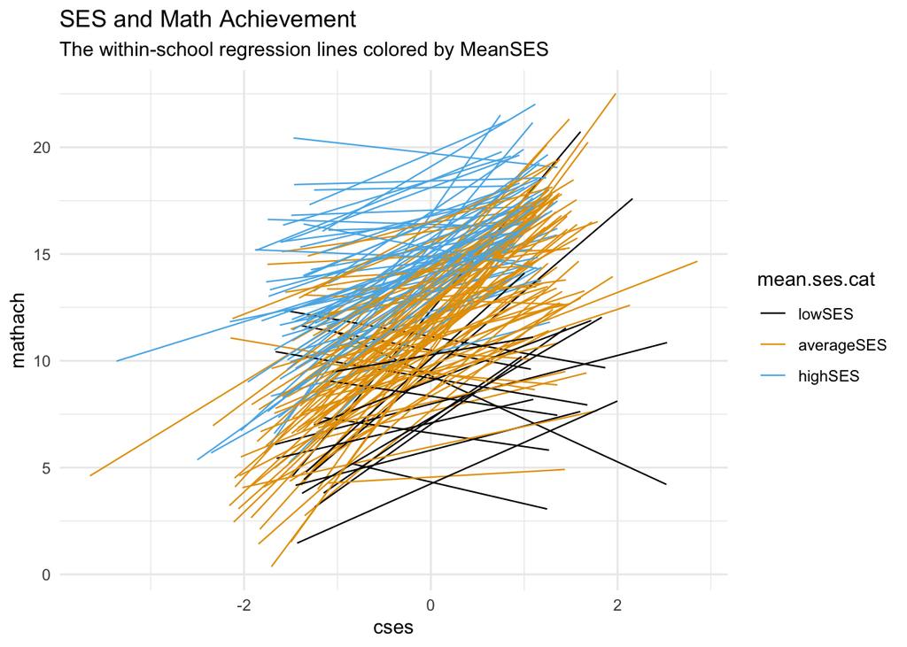

```r
cbbPalette <- c("#000000", "#E69F00", "#56B4E9", "#009E73", "#F0E442", "#0072B2", "#D55E00", "#CC79A7")

ggplot(data = HSB, aes(x = cses, y = mathach, col = mean.ses.cat, group = school)) +
  #geom_point(size = 1, alpha = .7, position = "jitter") +
  theme_minimal() +
  scale_color_manual(values = cbbPalette[1:3]) +
  geom_smooth(method = lm,
              se     = FALSE,
              size   = .4,
              alpha  = .7) + # to add regression line
  labs(title    = "SES and Math Achievement",
       subtitle = "The within-school regression lines colored by MeanSES")
```

As can be seen, there is a clear difference in the slopes across the 3 categories of Mean SES. Note that in this way, we’re really seeing the multilevel part in action. We have 2 sample levels, one of the 7185 students, and now we can see that the 160 schools make up a second (random) sample. This random sample has systematic components, one of them being Mean SES. But instead of just looking at the relation between this level-2 systematic component and a measurement, we looking at the relationship between the level-2 systematic component and the strength of a level-1 relationship.

### Plotting only a sample of schools

Sometimes it’s easier to plot only some of the schools. Here is code that takes a sample of schools and plots them. Note, every time you run the `schools <- sample(HSB$school, 50)` command it will select different schools, so the plot will look a bit different every time that happens.

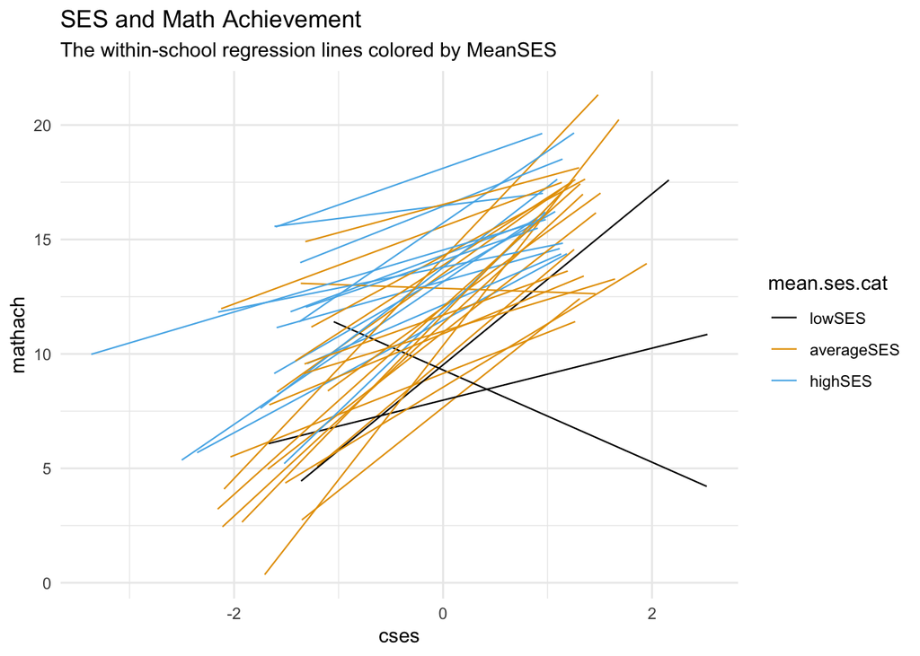

```r
schools <- sample(HSB$school, 50)

Sampledata <- HSB[is.element(HSB$school,schools), ]

ggplot(data = Sampledata, aes(x = cses, y = mathach, col = mean.ses.cat, group = school)) +
  #geom_point(size = 1, alpha = .7, position = "jitter") +
  theme_minimal() +
  scale_color_manual(values = cbbPalette[1:3]) +
  geom_smooth(method = lm,
              se     = FALSE,
              size   = .4,
              alpha  = .7) + # to add regression line
  labs(title    = "SES and Math Achievement",
       subtitle = "The within-school regression lines colored by MeanSES")
```

## Building a model with deviance tests

Although we’ve used the t-values above as proxies for significance tests, we can also test the variance terms. Here, we’re going back a step to see if we need to actually specify predictors at level-2.

Let’s now see how we can “test” the significance of the random intercepts and slopes (the variance terms). This follows p. 84 of Raudenbush and Bryk (2002).

## Fit the models to compare

We already have our test model: Model 4 with intercepts and slopes as outcomes (implying that both intercepts and slopes are random)

That model has the following variance components with $\tau_{10} = \tau_{01}$

$$\begin{bmatrix}
\tau_{00} & \tau_{01} \\
\tau_{10} &\tau_{11}
\end{bmatrix}$$
We will test the null hypothesis:

$$H_{0}: \tau_{10} = \tau_{01} = \tau_{11} = 0$$
That is accomplished by fitting a model with random intercepts only model:

- Level 1
  - $Y_{ij} = \beta_{0j} + \beta_{1j}(cses_{ij}) \beta_{2j}(cses_{ij} \times mean.ses{j})+ \beta_{3j}(cses_{ij} \times Sector{j}) + r_{ij}$
- Level 2
  - $\beta_{0j} = \gamma_{00} + \gamma_{01}(mean.ses_{j}) + \gamma_{02}(Sector_{j}) + u_{0j}$
  - $\beta_{1j} = \gamma_{10}$
  - $\beta_{2j} = \gamma_{20}$
  - $\beta_{3j} = \gamma_{30}$

Which would look like this as a combined model:

$$Y_{ij} = \gamma_{00} + \gamma_{01}(mean.ses_{j}) +
\gamma_{02}(Sector_{j}) + \gamma_{10}(cses) + \gamma_{20}(cses_{ij}
\times mean.ses{j})+ \gamma_{30}(cses_{ij} \times Sector{j}) + r_{ij}$$
In lme4 language we have:

```r
mod4_test <- lmer(mathach ~ cses*mean.ses + cses*sector + (1 | school), data = HSB)

# model 4_test VCOV
VarCorr(mod4_test)
```

```
##  Groups   Name        Std.Dev.
##  school   (Intercept) 1.5412
##  Residual             6.0635
```

```r
# model 4 VCOV
VarCorr(mod4)
```

```
##  Groups   Name        Std.Dev. Corr
##  school   (Intercept) 1.54259
##           cses        0.31787  0.391
##  Residual             6.05980
```

Note that `mod4_test` indeed has 2 fewer unique variance components.

Now we must perform the likelihood ratio test, which is a test of the Deviance statistics from the models. For a model to fit better, the deviance must be smaller (it is like a residual).

Below is code using `anova()`.

**Note** when testing variance components, we should specify `refit = FALSE` to retain the `REML` results of our models. See Snijders & Bosker for more.

```r
anova(mod4, mod4_test, refit = F)
```

```
## Data: HSB
## Models:
## mod4_test: mathach ~ cses * mean.ses + cses * sector + (1 | school)
## mod4: mathach ~ cses * mean.ses + cses * sector + (cses | school)
##           npar   AIC   BIC logLik deviance  Chisq Df Pr(>Chisq)
## mod4_test    8 46521 46576 -23252    46505
## mod4        10 46524 46592 -23252    46504 1.1241  2       0.57
```

Here we see that actually, the null hypothesis is retained, the model without random slopes fits just as well as that with the random slopes.